# MATH 391 Homework 11 R Component

Due December 3, 2014

## Terminology/Concept Refresher:

- A *population distribution* i.e. PDF $f(x)$ characterizes the random behavior of *individual* observations $X_i$. In other words, it is the distribution from which individual observed $x_i$ originate.
- A *(random) sample of size $n$* is a set of $n$ IID random variables $X_1, \ldots, X_n$ from the population distribution.
- A *statistic* is a function from $\mathbb{R}^n$ to $\mathbb{R}$ of the sample to a scalar quantity, such as the sample mean $\overline{X}$, the sample variance $S^2$, the minimum/maximum, etc. In our case, we’ll be considering the sample mean.
- A *sampling distribution* is the probability distribution characterizing the random behavior of statistic. In our case, it is the distribution from which observed $\overline{x}$ originate.
- The *standard error* is the standard deviation specifically associated with a sampling distribution.
- The Central Limit Theorem states that the asymptotic (sampling) distribution of the sample mean $\overline{X}$ is Normal with mean $\mu$ and standard error $SE=\sqrt{\frac{\sigma^2}{n}} = \frac{\sigma}{\sqrt{n}}$, *regardless* of the population distribution $f(x)$. Or stated different, the distribution is *approximately* normal.

## Central Limit Theorem Example

We demonstrate the Central Limit Theorem using a $\chi^2$ distribution with $df=3$ degrees of freedom as our population distribution $f(x)$.

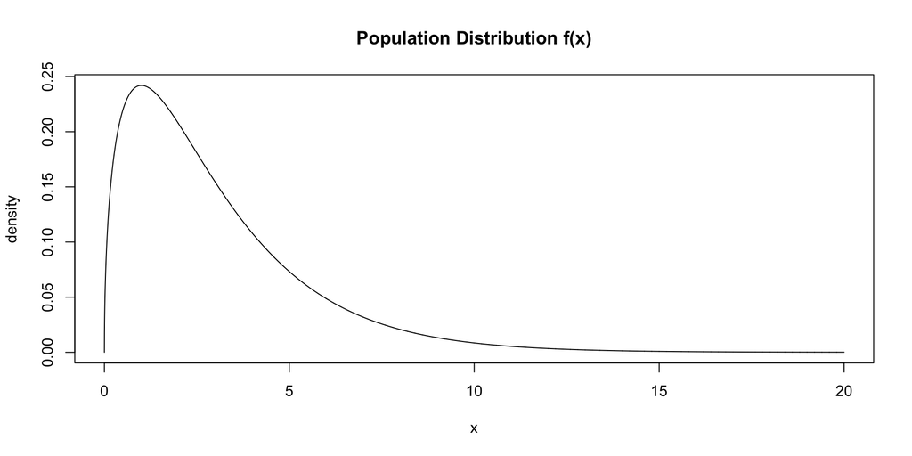

We will demonstrate the effect on the sampling distribution of the sample mean as $n \longrightarrow \infty$. We will sample `n.sim=10000` observations $\overline{x}_n$ from the sampling distribution, where each $\overline{x}_n$ is based on a sample of size $n$ from the population distribution $f(x)$. Note: 10000 was an arbitrarily chosen large number.

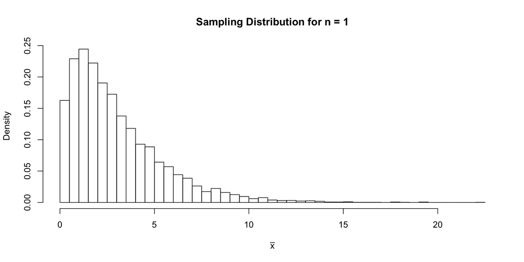

```r
n <- 1
df <- 3
n.sim <- 10000
x.bar.vector <- rep(0, n.sim)
for(i in 1:n.sim){
  sample <- rchisq(n, df=df)
  x.bar.vector[i] <- mean(sample)
}

title <- paste("Sampling Distribution for n =", n)
hist(x.bar.vector, breaks=50, xlab=expression(bar(x)), prob=TRUE, main=title)
```

```r
#curve(dnorm(x, mean=df, sd=sqrt(2*df/n)), from=df-6*sqrt(2*df/n), to=df+6*sqrt(2*df/n), n=1000, add=TRUE, col="red", lwd=2)
```

### Questions

No need to include the code for your responses.

1. When $n=1$, what can we say about the sampling distribution?
2. When the population distribution is a $\chi^2$ with $df=3$, about what sample size $n$ do you need before the Central Limit Theorem “kicks in”?
3. Compare the sampling distributions of $\overline{X}_n$ based on $n=3$ observations from a $\chi^2$ with $df=3$ versus $df=300$. What do you observe?
4. Based on your above response, guess which attribute of the population distribution $f(x)$ determines the “efficiency” of the Central Limit Theorem?
5. For samples of size $n=27$ from a population that is $\chi^2$ with $df=3$, what is the approximate mean and standard error of the sampling distribution? Give the analytic value and not a value based on our simulations above.
6. For the scenario in 5, analytically compute the approximate proportion of observed sample means that will fall between 2.224 and 3.775. Sanity check your responses with a histogram of simulated values.
7. BONUS: Uncomment the line with the `curve()` function above and replace `MEAN`,`SD`,`FROM` and `TO` with the appropriate values so that the superimposed curve matches the histogram for large values of $n$.

### Answers

```r
pnorm(1.645) - pnorm(-1.647)
```

```
## [1] 0.9002361
```

## Your Turn

### Wacky PDF Revisited

Let’s consider the same PDF $f(x)$ from Written HW 4 Question 3 and R HW 5 but with a gap of size 7 between the two modes. Let’s call this the “gap” distribution with PDF:
$$f(x) = \left\{
\begin{array}{ll}
\exp(x)/2 & \mbox{for } x < 0 \\
0 & \mbox{for } 0 \leq x < 7 \\
\exp(7-x)/2 & \mbox{for } x \geq 7 \\
\end{array}
\right.$$

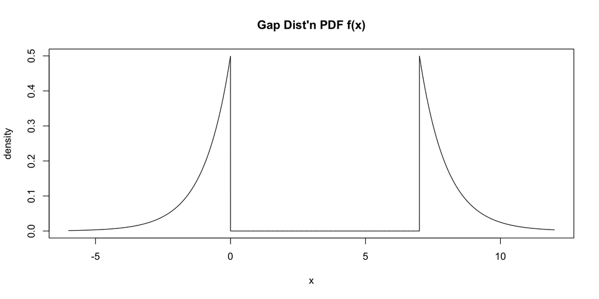

### Simulating these Random Variables

The inverse CDF function $F^{-1}(y)$ for $y \in (0,1)$ is

```r
F.inv <- function(y) {
  if (y < 0.5) {
    x <- log(2*y)
  }
  if (y > 0.5) {
    x <- 7 - log(2*(1-y))
  }
  return(x)
}
```

Modifying code from the solutions to R HW 5, write a function `rgap(n)` that has

- Input: the number `n` of values we want to simulate
- Output: a vector of length `n` of simulated values from the gap distribution.

Test your code out with the (commented) histogram code.

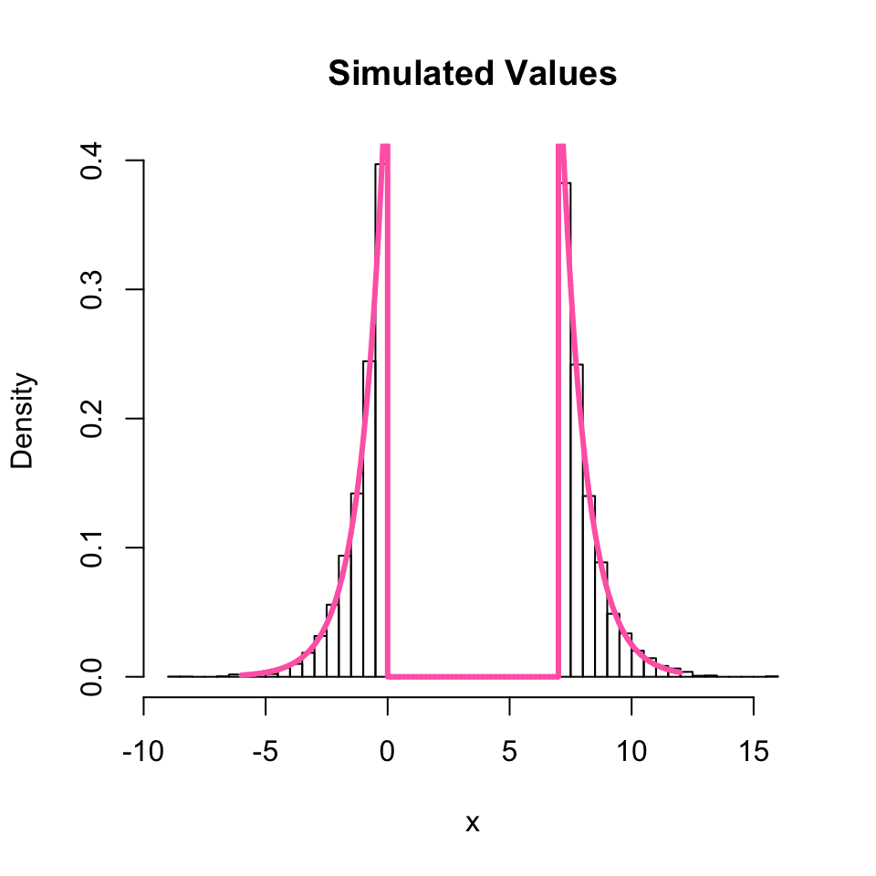

```r
rgap <- function(n){
  y <- runif(n, min=0, max=1)
  output <- rep(0, n)
  for(i in 1:length(output)) {
    output[i] <- F.inv(y[i])
  }
  return(output)
}

# Histogram of simulated values
hist(rgap(10000), xlab="x", main="Simulated Values", prob=TRUE, breaks=50)
lines(domain, pdf.values, col="hotpink", lwd=3)
```

### Comparison of Different Sample Sizes

Now we will compare the sampling distributions for $n=1, 2, 4, 6, 10$ and a sixth value of your choice where you think the Central Limit Theorem has “kicked in”. Again, each histogram will be based on 10000 draws from the sampling distribution, i.e. 10000 values of $\overline{x}$. We split the plot panel into 3 rows and 2 columns and make use of a nested for loop indexed by `j` to achieve this. Use the code from earlier to demonstrate the Central Limit Theorem for the different values of $n$.

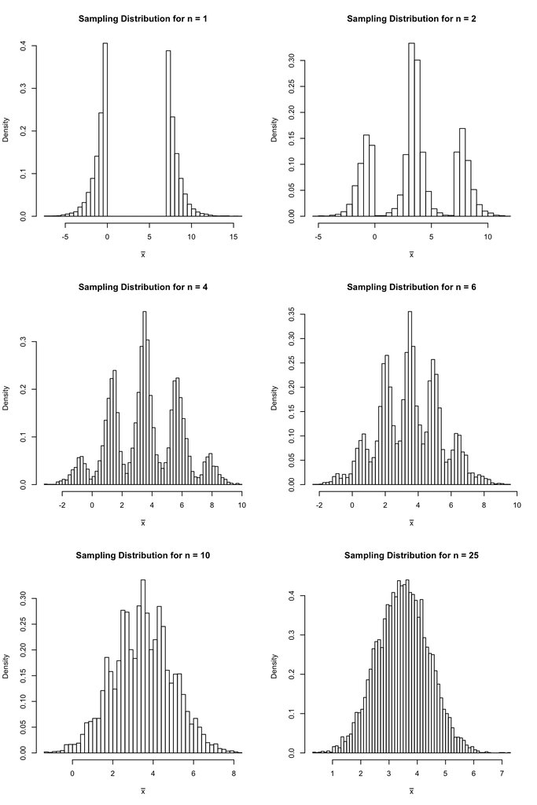

```r
n.sim <- 10000
# n <- c(1, 2, 4, 6, 10, INSERT_YOUR_VALUE)
n <- c(1, 2, 4, 6, 10, 25)

par(mfrow=c(3,2))
for(j in 1:length(n)) {

  x.bar.vector <- rep(0, n.sim)
  for(i in 1:n.sim){
    sample <- rgap(n[j])
    x.bar.vector[i] <- mean(sample)
  }
  title <- paste("Sampling Distribution for n =", n[j])
  hist(x.bar.vector, breaks=50, xlab=expression(bar(x)), prob=TRUE,
       main=title)

}
```

We see that for small values of $n$, the distribution of sample means exhibits very odd behavior, but as $n$ approaches 25, things look sufficiently normal.